# Chapter 5 tables and graphs

2021-02-02

```r
library(xtable)
library(countrycode)
library(plm)
library(maxLik)
options(scipen = 999)
```

# Prepare the data

Get the data which is created by the `dataprep.R`.

```r
rm(list = ls())
source("r-codes/dataprep.R")
```

```
## restatapi: - config file with the API version 1 loaded from GitHub (the 'current' API version number is 1).
##            - 4 from the 32 cores are used for parallel computing.
##            - 'libcurl' will be used for file download.
##            - the Table of contents (TOC) was not pre-loaded into the deafult cache ('.restatapi_env').
```

```
## No data retrieved for the given filter(s), because the results are too big to download immediately through the REST API. The whole dataset is downloaded through the raw download and the filters are applied locally.
```

```
## Info: (Data scanned: 1.01 GB)
```

```r
head(oja_capture)
```

```
##    general_id idcountry  grab_date expire_date idesco_level_2 nace
## 1:  428159149        FR 2019-10-07  2020-02-04             81    N
## 2:   94340657        DE 2018-08-20  2018-12-18             72    N
## 3:   93109091        FR 2018-08-25  2018-12-23             75    F
## 4:  176954046        DE 2019-02-08  2019-06-08             74    J
## 5:  335766704        IT 2019-07-03  2019-10-31             52    G
## 6:  299315065        LT 2019-06-10  2019-10-08             51    N
##               source           source_category N t2018Q3 t2018Q4 t2019Q1
## 1:            NEUVOO         Job search engine 2   FALSE   FALSE   FALSE
## 2: DE_ARBEITSAGENTUR Public employment service 1    TRUE   FALSE   FALSE
## 3:            ADZUNA         Job search engine 2    TRUE   FALSE   FALSE
## 4:            ADZUNA         Job search engine 1   FALSE   FALSE    TRUE
## 5:   IT_CLICCALAVORO        Employment website 1   FALSE   FALSE   FALSE
## 6:          CVONLINE         Job search engine 1   FALSE   FALSE   FALSE
##    t2019Q2 t2019Q3 t2019Q4 t2018Q3_days t2018Q4_days t2019Q1_days t2019Q2_days
## 1:   FALSE   FALSE    TRUE           NA           NA           NA           NA
## 2:   FALSE   FALSE   FALSE           41           NA           NA           NA
## 3:   FALSE   FALSE   FALSE           36           NA           NA           NA
## 4:   FALSE   FALSE   FALSE           NA           NA           51           NA
## 5:   FALSE    TRUE   FALSE           NA           NA           NA           NA
## 6:    TRUE    TRUE   FALSE           NA           NA           NA           20
##    t2019Q3_days t2019Q4_days count_quarts
## 1:           NA           85            1
## 2:           NA           NA            1
## 3:           NA           NA            1
## 4:           NA           NA            1
## 5:           89           NA            1
## 6:          112           NA            2
```

```r
setkeyv(oja_capture, cols = c("general_id", "idcountry", "grab_date", "expire_date",
                                  "idesco_level_2", "nace", "source", "source_category",
                                  "t2018Q3", "t2018Q4", "t2019Q1", "t2019Q2", "t2019Q3", "t2019Q4"))
oja_capture[, occup := substr(idesco_level_2,1,1)]
```

# Figure 17

Distribution of number of advertisements by quarters and days to the end of given quarter based on `grab_date` variable

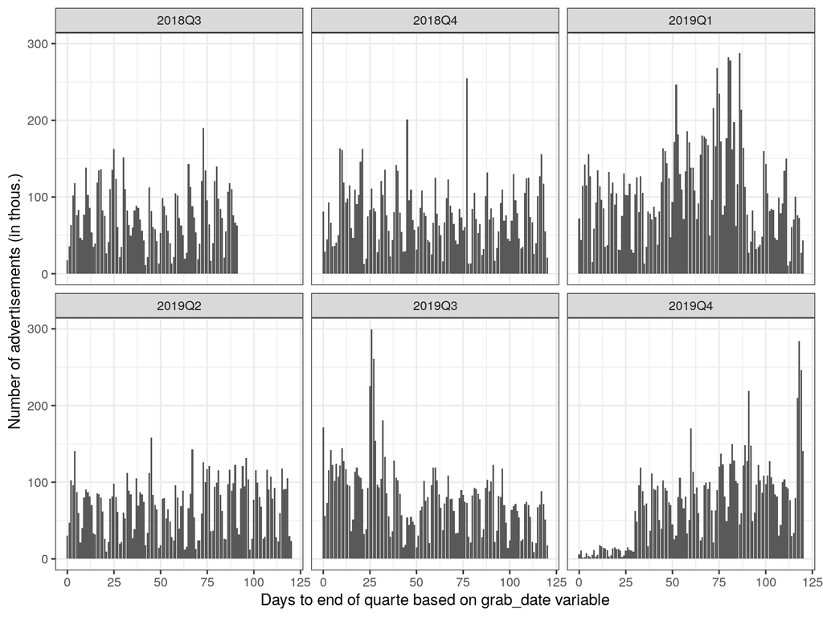

```r
# (fig-times-dist.png)
rbind(oja_db[t2018Q3 == TRUE,.N, .(vals=t2018Q3_days)][, quar:="2018Q3"],
      oja_db[t2018Q4 == TRUE,.N, .(vals=t2018Q4_days)][, quar:="2018Q4"],
      oja_db[t2019Q1 == TRUE,.N, .(vals=t2019Q1_days)][, quar:="2019Q1"],
      oja_db[t2019Q2 == TRUE,.N, .(vals=t2019Q2_days)][, quar:="2019Q2"],
      oja_db[t2019Q3 == TRUE,.N, .(vals=t2019Q3_days)][, quar:="2019Q3"],
      oja_db[t2019Q4 == TRUE,.N, .(vals=t2019Q4_days)][, quar:="2019Q4"]) -> times

times %>%
  ggplot(data = ., aes(x = vals, y = N/1000)) +
  geom_col() +
  facet_wrap(~quar) +
  theme_bw() +
  labs(x = "Days to end of quarte based on grab_date variable", y = "Number of advertisements (in thous.)") -> p
plot(p)
```

# Figure 18

Comparison of estimates based on JVS (solid red line; seasonally unadjusted data), OJA data without trimming (solid black line) and trimmed data (solid gray lines)

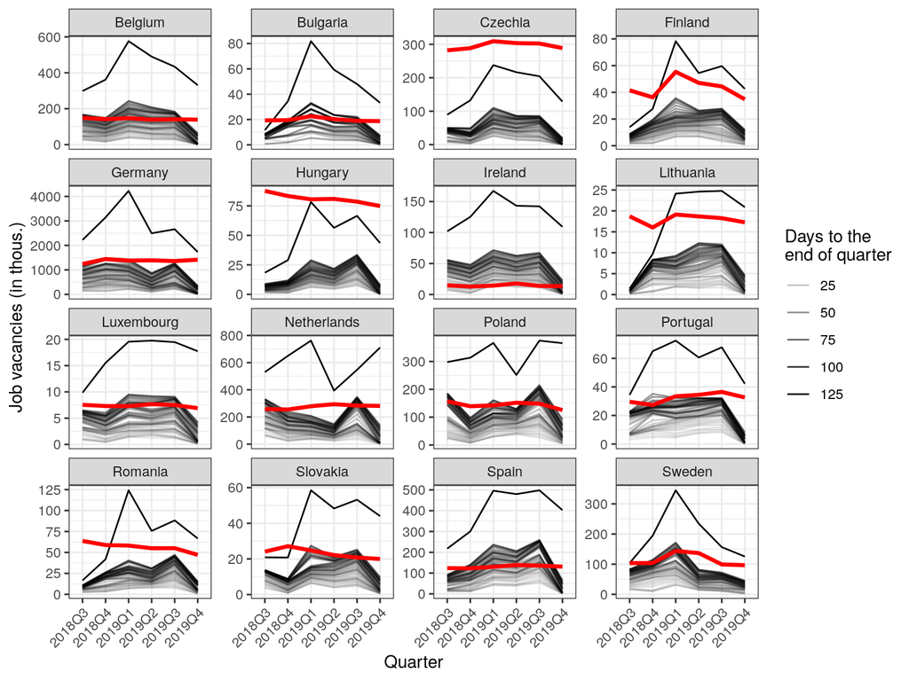

```r
# (fig-trimed.png)
# Removing number of advertisements based on time -- trimming

stats_quart_2018Q3 <- list()
stats_quart_2018Q4 <- list()
stats_quart_2019Q1 <- list()
stats_quart_2019Q2 <- list()
stats_quart_2019Q3 <- list()
stats_quart_2019Q4 <- list()

days_pass <- c(130,seq(from  = 7, to = 50, by = 1))

for (d in days_pass) {
  stats_quart_2018Q3[[d]] <- oja_capture[ t2018Q3 & t2018Q3_days < d, .N, .(general_id, idcountry)][, .N, idcountry]
  stats_quart_2018Q4[[d]] <- oja_capture[ t2018Q4 & t2018Q4_days < d, .N, .(general_id, idcountry)][, .N, idcountry]
  stats_quart_2019Q1[[d]] <- oja_capture[ t2019Q1 & t2019Q1_days < d, .N, .(general_id, idcountry)][, .N, idcountry]
  stats_quart_2019Q2[[d]] <- oja_capture[ t2019Q2 & t2019Q2_days < d, .N, .(general_id, idcountry)][, .N, idcountry]
  stats_quart_2019Q3[[d]] <- oja_capture[ t2019Q3 & t2019Q3_days < d, .N, .(general_id, idcountry)][, .N, idcountry]
  stats_quart_2019Q4[[d]] <- oja_capture[ t2019Q4 & t2019Q4_days < d, .N, .(general_id, idcountry)][, .N, idcountry]
}

stats_quart_2018Q3_l <- rbindlist(stats_quart_2018Q3, idcol = "remove") %>% mutate(quarter = "2018Q3")
stats_quart_2018Q4_l <- rbindlist(stats_quart_2018Q4, idcol = "remove") %>% mutate(quarter = "2018Q4")
stats_quart_2019Q1_l <- rbindlist(stats_quart_2019Q1, idcol = "remove") %>% mutate(quarter = "2019Q1")
stats_quart_2019Q2_l <- rbindlist(stats_quart_2019Q2, idcol = "remove") %>% mutate(quarter = "2019Q2")
stats_quart_2019Q3_l <- rbindlist(stats_quart_2019Q3, idcol = "remove") %>% mutate(quarter = "2019Q3")
stats_quart_2019Q4_l <- rbindlist(stats_quart_2019Q4, idcol = "remove") %>% mutate(quarter = "2019Q4")

stats_quarts <- bind_rows(stats_quart_2018Q3_l,stats_quart_2018Q4_l,stats_quart_2019Q1_l,stats_quart_2019Q2_l,
                          stats_quart_2019Q3_l,stats_quart_2019Q4_l)

stats_quarts %>%
  left_join(jvs %>% filter(s_adj == "NSA") %>% select(geo, yq, jvs),
            by = c("quarter" = "yq", "idcountry" = "geo")) %>%
  filter(!is.na(jvs)) %>%
  filter(idcountry != "AT") %>%
  mutate(idcountry = countrycode(idcountry, "eurostat","country.name"))  %>%
  select(idcountry, quarter, oja = N, jvs, remove) %>%
  ggplot(data = .) +
  geom_line(aes(x = quarter, y = oja/1000, group = remove, alpha = remove)) +
  geom_line(aes(x = quarter, y = jvs/1000, group = 1), color = "red", size = 1.2) +
  facet_wrap(~idcountry, scales = "free_y") +
  scale_color_brewer(name = "Source", type = "qual", palette = "Set1") +
  theme_bw() +
  labs(x = "Quarter", y = "Job vacancies (in thous.)", alpha = "Days to the \nend of quarter") +
  theme(axis.text.x = element_text(angle = 45, vjust=1,hjust=1)) -> p
plot(p)
```

# Figure 19

Comparison of absolute difference of estimates between OJA trimmed estimates with JVS for each quarter

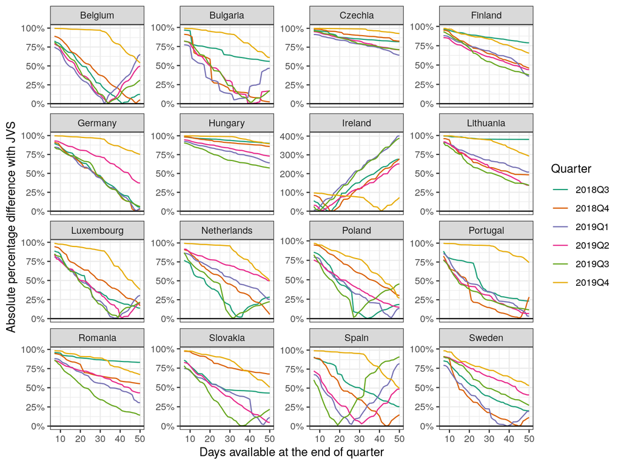

```r
# (fig-trimed-diffs.png)
stats_quarts %>%
  filter(remove != 130) %>%
  left_join(jvs %>% filter(s_adj == "NSA") %>% select(geo, yq, jvs),
            by = c("quarter" = "yq", "idcountry" = "geo")) %>%
  mutate(bias = abs((N - jvs)/jvs)) %>%
  filter(!idcountry %in% c("AT"))  %>%
  filter(!is.na(jvs)) %>%
  mutate(idcountry = countrycode(idcountry, "eurostat","country.name")) %>%
  ggplot(data = ., aes(x = remove, y = bias, color = quarter, group = quarter)) +
  geom_line()   +
  facet_wrap(~idcountry, scales = "free_y") +
  scale_color_brewer(name  = "Quarter", type = "qual", palette = "Dark2") +
  theme_bw() +
  scale_y_continuous(labels = scales::percent) +
  geom_hline(yintercept = 0, color = "black", type = "dashed") +
  labs(x = "Days available at the end of quarter", y = "Absolute percentage difference with JVS") -> p
plot(p)
```

# Figure 20

```r
# smaller countries
# (fig-small-est.png)
countries <- c("CZ", "IE", "BG",  "PT", "RO") #, "HU", "SE", "LU""SK", "LT",, "FI")
days <- seq(30, 60, 5)

result_countries <- list()

result_2018Q3 <- list()
result_2018Q4 <- list()
result_2019Q1 <- list()
result_2019Q2 <- list()
result_2019Q3 <- list()
result_2019Q4 <- list()



for (co in countries) {
  print(co)
  k <- 1
  for (i in days) {
    print(k)
    print("t2018Q3")
    suppressMessages(suppressWarnings(
      result_2018Q3[[k]]<- estimate_population_size(data = oja_capture, country = co, quarter = "t2018Q3", quarter_days = "t2018Q3_days", trunc = i)
    ))
    print("t2018Q4")
    suppressMessages(suppressWarnings(
      result_2018Q4[[k]]<- estimate_population_size(data = oja_capture, country = co, quarter = "t2018Q4", quarter_days = "t2018Q4_days", trunc = i)
    ))
    print("t2019Q1")
    suppressMessages(suppressWarnings(
      result_2019Q1[[k]]<- estimate_population_size(data = oja_capture, country = co, quarter = "t2019Q1", quarter_days = "t2019Q1_days", trunc = i)
    ))
    print("t2019Q2")
    suppressMessages(suppressWarnings(
      result_2019Q2[[k]]<- estimate_population_size(data = oja_capture, country = co, quarter = "t2019Q2", quarter_days = "t2019Q2_days", trunc = i)
    ))
    print("t2019Q3")
    suppressMessages(suppressWarnings(
      result_2019Q3[[k]]<- estimate_population_size(data = oja_capture, country = co, quarter = "t2019Q3", quarter_days = "t2019Q3_days", trunc = i)
    ))
    k <- k + 1
  }
  result_countries[[co]] <- list(result_2018Q3 = result_2018Q3, result_2018Q4 = result_2018Q4,
                                 result_2019Q1 = result_2019Q1,
                                 result_2019Q2 = result_2019Q2, result_2019Q3 = result_2019Q3)
}
```

```
## [1] "CZ"
## [1] 1
## [1] "t2018Q3"
## [1] "t2018Q4"
## [1] "t2019Q1"
## [1] "t2019Q2"
## [1] "t2019Q3"
## [1] 2
## [1] "t2018Q3"
## [1] "t2018Q4"
## [1] "t2019Q1"
## [1] "t2019Q2"
## [1] "t2019Q3"
## [1] 3
## [1] "t2018Q3"
```

[output cut: 200 more lines]

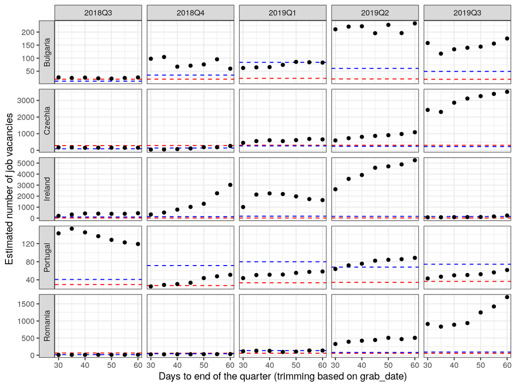

```r
wyniki_est <- list()
l <- 1
for (i in 1:length(result_countries)) {
  for (j in 1:5) {
    for (k in 1:length(days)) {
      l <- l  + 1
      wyniki_est[[l]] <- data.frame(country = countries[i],
                                    quarter = names(result_countries[[1]])[j],
                                    days = days[k],
                                    boots = result_countries[[i]][[j]][[k]]$boots)

    }
  }
}
wyniki_est_df <- rbindlist(wyniki_est)


oja_capture_small <- oja_capture[idcountry %in% countries, lapply(.SD, sum, na.rm=TRUE), .(country=idcountry),
                                         .SDcols = t2018Q3:t2019Q4] %>%
  gather(quarter, oja, -country) %>%
  mutate(quarter = str_remove(quarter, "t"),
         oja  = oja/1000)



wyniki_est_df %>%
  group_by(country, quarter=str_remove(quarter, 'result_'), days) %>%
  summarise(med = median(boots)/1000,
            me = mean(boots)/1000,
            q025 = quantile(boots, 0.025)/1000,
            q975 = quantile(boots, 0.975)/1000) %>%
  ungroup() %>%
  left_join(jvs %>% filter(s_adj == "NSA") %>%
              select(country = geo, quarter=yq, jvs)) %>%
  left_join(oja_capture_small) %>%
  mutate(jvs = jvs / 1000) %>%
  mutate(country = countrycode(country, "eurostat","country.name"))  %>%
  ggplot(data = ., aes(x = days)) +
  #geom_errorbar(aes(ymin = q025, y = med, ymax = q975)) +
  geom_hline(aes(yintercept = jvs), color = "red", linetype = "dashed") +
  geom_hline(aes(yintercept = oja), color = "blue", linetype = "dashed") +
  geom_point(aes(y = me)) +
  facet_grid(country ~ quarter, scales = "free_y", switch = "y") +
  scale_linetype_manual(name = "Source", values = c("red", "blue"), breaks  = c("jvs", "oja")) +
  theme_bw() +
  labs(x = "Days to end of the quarter (trimming based on grab_date)", y  = "Estimated number of job vacancies") -> p
plot(p)
```

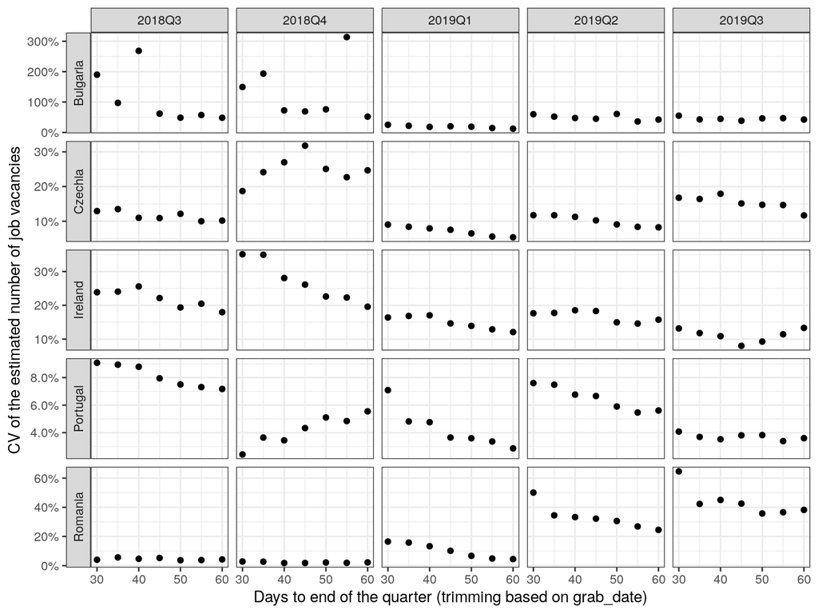

```r
# (fig-small-est-cv.png)

wyniki_est_df %>%
  group_by(country, quarter=str_remove(quarter, 'result_'), days) %>%
  summarise(med = median(boots)/1000,
            me = mean(boots)/1000,
            se = sd(boots)/1000,
            q025 = quantile(boots, 0.025)/1000,
            q975 = quantile(boots, 0.975)/1000) %>%
  ungroup() %>%
  left_join(jvs %>% filter(s_adj == "NSA") %>%
              select(country = geo, quarter=yq, jvs)) %>%
  left_join(oja_capture_small) %>%
  mutate(jvs = jvs / 1000) %>%
  mutate(country = countrycode(country, "eurostat","country.name"))  %>%
  ggplot(data = ., aes(x = days)) +
  #geom_errorbar(aes(ymin = q025, y = med, ymax = q975)) +
  #geom_hline(aes(yintercept = jvs), color = "red", linetype = "dashed") +
  #geom_hline(aes(yintercept = oja), color = "blue", linetype = "dashed") +
  geom_point(aes(y = se/me)) +
  facet_grid(country ~ quarter, scales = "free_y", switch = "y") +
  scale_y_continuous(labels = scales::percent) +
  #scale_linetype_manual(name = "Source", values = c("red", "blue"), breaks  = c("jvs", "oja")) +
  theme_bw() +
  labs(x = "Days to end of the quarter (trimming based on grab_date)", y  = "CV of the estimated number of job vacancies") -> p
plot(p)
```

# Table 14

Comparison of estimates (in thous.) based on JVS, OJA data without trimming and zero-one-truncated Poisson capture-recapture size estimator under different trimming to 40 days

```r
wyniki_est_df %>%
  group_by(country, quarter=str_remove(quarter, 'result_'), days) %>%
  summarise(med = median(boots)/1000,
            me = mean(boots)/1000,
            se = sd(boots)/1000,
            cv = se/me*100,
            q025 = quantile(boots, 0.025)/1000,
            q975 = quantile(boots, 0.975)/1000) %>%
  ungroup() %>%
  left_join(jvs %>% filter(s_adj == "NSA") %>%
              select(country = geo, quarter=yq, jvs)) %>%
  left_join(oja_capture_small) %>%
  left_join(stats_quarts %>% filter(remove == 40) %>% rename(country=idcountry)) %>%
  mutate(jvs = jvs / 1000,
         N = N/1000) %>%
  mutate(country = countrycode(country, "eurostat","country.name"))  %>%
  filter(days == 40) %>%
  select(country, quarter, JVS =jvs, OJA = oja, trimmed = N, Proposed = me, CV = cv) %>%
  xtable(caption = "Comparison of estimates (in thous.) based on JVS, OJA data without trimming and zero-one-truncated Poisson capture-recapture size estimator under different trimming to 40 days", digits = 1) %>%
  print.xtable(include.rownames = F, caption.placement = "top")
```

```
## % latex table generated in R 4.0.3 by xtable 1.8-4 package
## % Tue Feb  2 14:28:39 2021
## \begin{table}[ht]
## \centering
## \caption{Comparison of estimates (in thous.) based on JVS, OJA data without trimming and zero-one-truncated Poisson capture-recapture size estimator under different trimming to 40 days}
## \begin{tabular}{llrrrrr}
##   \hline
## country & quarter & JVS & OJA & trimmed & Proposed & CV \\
##   \hline
## Bulgaria & 2018Q3 & 19.3 & 11.9 & 8.0 & 25.5 & 268.4 \\
##   Bulgaria & 2018Q4 & 19.5 & 35.0 & 17.7 & 67.3 & 72.5 \\
##   Bulgaria & 2019Q1 & 22.6 & 83.9 & 27.7 & 65.6 & 18.2 \\
##   Bulgaria & 2019Q2 & 20.3 & 60.7 & 20.2 & 222.0 & 47.4 \\
##   Bulgaria & 2019Q3 & 18.9 & 49.1 & 18.5 & 133.9 & 44.7 \\
##   Czechia & 2018Q3 & 282.1 & 93.1 & 45.7 & 152.6 & 11.0 \\
##   Czechia & 2018Q4 & 288.5 & 138.4 & 33.9 & 71.0 & 27.0 \\
##   Czechia & 2019Q1 & 309.3 & 264.8 & 79.9 & 605.3 & 7.9 \\
##   Czechia & 2019Q2 & 303.6 & 239.2 & 74.3 & 808.6 & 11.2 \\
##   Czechia & 2019Q3 & 302.4 & 225.0 & 74.6 & 2862.9 & 17.9 \\
##   Ireland & 2018Q3 & 14.8 & 105.5 & 47.6 & 424.2 & 25.6 \\
##   Ireland & 2018Q4 & 12.8 & 135.3 & 38.7 & 773.6 & 28.1 \\
##   Ireland & 2019Q1 & 14.3 & 180.3 & 58.0 & 2245.0 & 17.0 \\
##   Ireland & 2019Q2 & 17.8 & 161.8 & 50.1 & 3918.3 & 18.5 \\
##   Ireland & 2019Q3 & 13.8 & 149.9 & 55.9 & 89.5 & 10.9 \\
##   Portugal & 2018Q3 & 29.6 & 40.8 & 21.5 & 144.8 & 8.8 \\
##   Portugal & 2018Q4 & 27.4 & 71.5 & 26.1 & 30.6 & 3.4 \\
##   Portugal & 2019Q1 & 33.5 & 79.9 & 26.2 & 51.2 & 4.8 \\
##   Portugal & 2019Q2 & 34.4 & 68.1 & 29.2 & 75.6 & 6.8 \\
##   Portugal & 2019Q3 & 36.5 & 74.4 & 30.8 & 50.0 & 3.5 \\
##   Romania & 2018Q3 & 63.7 & 17.1 & 9.9 & 11.3 & 4.7 \\
##   Romania & 2018Q4 & 58.8 & 43.2 & 24.2 & 26.7 & 1.8 \\
##   Romania & 2019Q1 & 58.2 & 134.3 & 30.2 & 126.9 & 13.3 \\
##   Romania & 2019Q2 & 55.0 & 80.2 & 24.9 & 423.3 & 33.3 \\
##   Romania & 2019Q3 & 55.0 & 91.9 & 42.9 & 890.0 & 45.0 \\
##    \hline
## \end{tabular}
## \end{table}
```

# Figure 21

Comparison of estimates based on JVS (red dashed line), OJA data without trimming (blue dashed line) and zero-one-truncated capture-recapture size estimator under different trimming dates (7 to 30)

```r
# (fig-big-est.png)

## over 200k
countries <- c("BE", "ES", "DE", "NL", "PL")

days <- 7:30

result_countries <- list()

result_2018Q3 <- list()
result_2018Q4 <- list()
result_2019Q1 <- list()
result_2019Q2 <- list()
result_2019Q3 <- list()
result_2019Q4 <- list()

for (co in countries[]) {
  print(co)
  k <- 1
  for (i in days) {
    print(k)
    print("t2018Q3")
    suppressMessages(suppressWarnings(
      result_2018Q3[[k]]<- estimate_population_size(data = oja_capture, country = co, quarter = "t2018Q3", quarter_days = "t2018Q3_days", trunc = i)
    ))
    print("t2018Q4")
    suppressMessages(suppressWarnings(
      result_2018Q4[[k]]<- estimate_population_size(data = oja_capture, country = co, quarter = "t2018Q4", quarter_days = "t2018Q4_days", trunc = i)
    ))
    print("t2019Q1")
    suppressMessages(suppressWarnings(
      result_2019Q1[[k]]<- estimate_population_size(data = oja_capture, country = co, quarter = "t2019Q1", quarter_days = "t2019Q1_days", trunc = i)
    ))
    print("t2019Q2")
    suppressMessages(suppressWarnings(
      result_2019Q2[[k]]<- estimate_population_size(data = oja_capture, country = co, quarter = "t2019Q2", quarter_days = "t2019Q2_days", trunc = i)
    ))
    print("t2019Q3")
    suppressMessages(suppressWarnings(
      result_2019Q3[[k]]<- estimate_population_size(data = oja_capture, country = co, quarter = "t2019Q3", quarter_days = "t2019Q3_days", trunc = i)
    ))
    k <- k + 1
  }
  result_countries[[co]] <- list(result_2018Q3 = result_2018Q3, result_2018Q4 = result_2018Q4,
                                 result_2019Q1 = result_2019Q1,
                                 result_2019Q2 = result_2019Q2, result_2019Q3 = result_2019Q3)
}
```

```
## [1] "BE"
## [1] 1
## [1] "t2018Q3"
## [1] "t2018Q4"
## [1] "t2019Q1"
## [1] "t2019Q2"
## [1] "t2019Q3"
## [1] 2
## [1] "t2018Q3"
## [1] "t2018Q4"
## [1] "t2019Q1"
## [1] "t2019Q2"
## [1] "t2019Q3"
## [1] 3
## [1] "t2018Q3"
```

[output cut: 710 more lines]

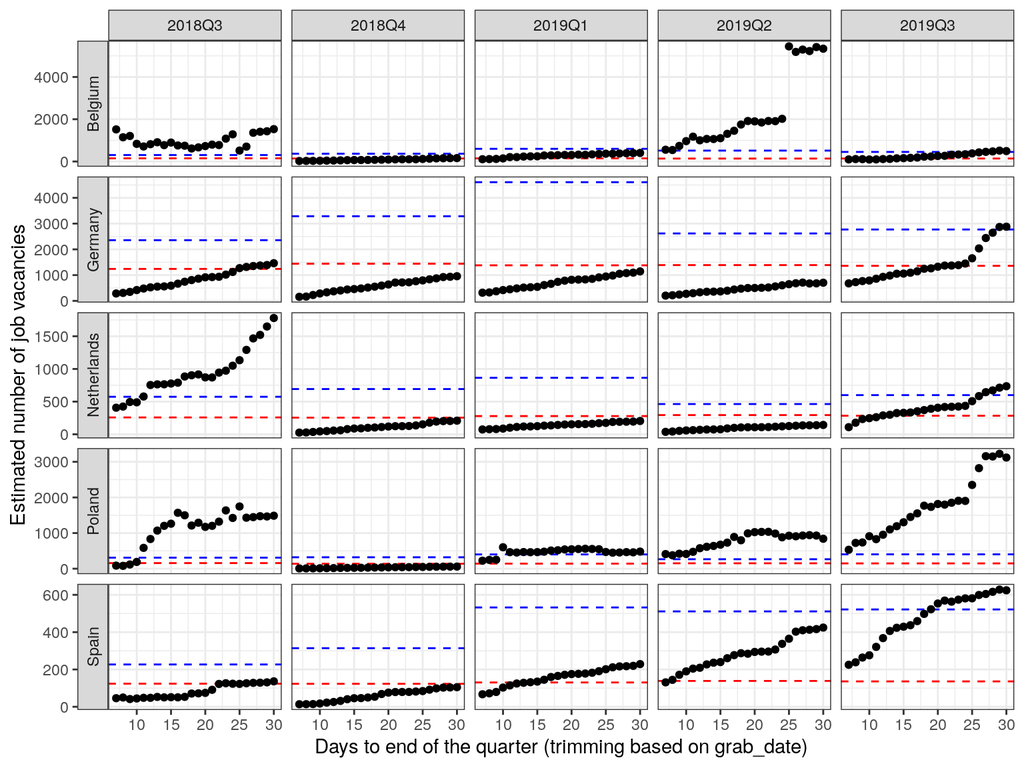

```r
wyniki_est <- list()

l <- 1
for (i in 1:length(result_countries)) {
  for (j in 1:5) {
    for (k in 1:length(days)) {
      l <- l  + 1
      wyniki_est[[l]] <- data.frame(country = countries[i],
                                    quarter = names(result_countries[[1]])[j],
                                    days = days[k],
                                    boots = result_countries[[i]][[j]][[k]]$boots)

    }
  }
}
wyniki_est_df <- rbindlist(wyniki_est)

oja_capture_big <- oja_capture[idcountry %in% c("BE", "ES", "DE", "NL", "PL"),
                                         lapply(.SD, sum, na.rm=TRUE), .(country=idcountry),
                                         .SDcols = t2018Q3:t2019Q4] %>%
  gather(quarter, oja, -country) %>%
  mutate(quarter = str_remove(quarter, "t"),
         oja  = oja/1000)


wyniki_est_df %>%
  group_by(country, quarter=str_remove(quarter, 'result_'), days) %>%
  summarise(med = median(boots)/1000,
            me = mean(boots)/1000,
            se = sd(boots) / 1000,
            q025 = quantile(boots, 0.025)/1000,
            q975 = quantile(boots, 0.975)/1000) %>%
  ungroup() %>%
  left_join(jvs %>% filter(s_adj == "NSA") %>%
              select(country = geo, quarter=yq, jvs)) %>%
  left_join(oja_capture_big) %>%
  mutate(jvs = jvs / 1000) %>%
  mutate(country = countrycode(country, "eurostat","country.name"))  %>%
  ggplot(data = ., aes(x = days)) +
  #geom_errorbar(aes(ymin = q025, y = med, ymax = q975)) +
  geom_hline(aes(yintercept = jvs), color = "red", linetype = "dashed") +
  geom_hline(aes(yintercept = oja), color = "blue", linetype = "dashed") +
  geom_point(aes(y = me)) +
  facet_grid(country ~ quarter, scales = "free_y", switch = "y") +
  scale_linetype_manual(name = "Source", values = c("red", "blue"), breaks  = c("jvs", "oja")) +
  #scale_y_continuous(labels = scales::percent) +
  theme_bw() +
  labs(x = "Days to end of the quarter (trimming based on grab_date)", y  = "Estimated number of job vacancies") -> p
plot(p)
```

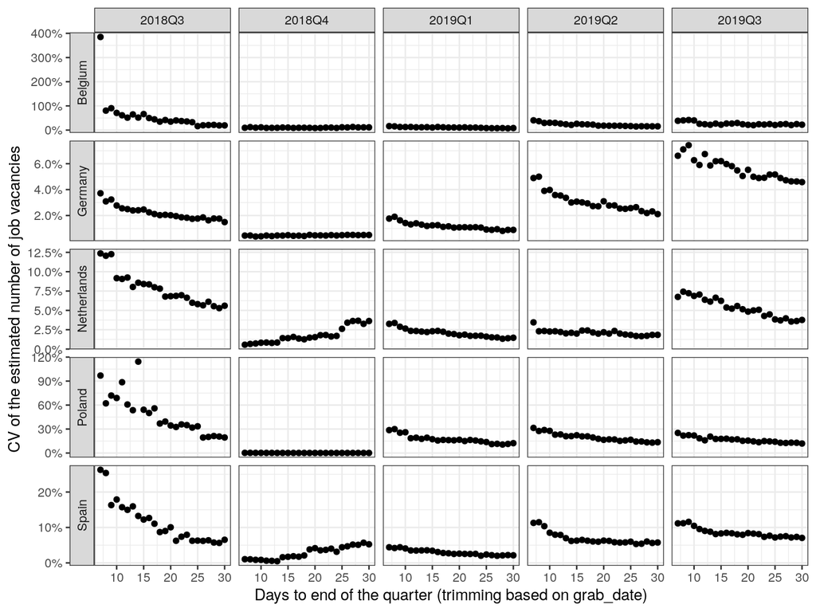

```r
# coefficient of variation
wyniki_est_df %>%
  group_by(country, quarter=str_remove(quarter, 'result_'), days) %>%
  summarise(med = median(boots)/1000,
            me = mean(boots)/1000,
            se = sd(boots) / 1000,
            q025 = quantile(boots, 0.025)/1000,
            q975 = quantile(boots, 0.975)/1000) %>%
  ungroup() %>%
  left_join(jvs %>% filter(s_adj == "NSA") %>%
              select(country = geo, quarter=yq, jvs)) %>%
  left_join(oja_capture_big) %>%
  mutate(jvs = jvs / 1000) %>%
  mutate(country = countrycode(country, "eurostat","country.name"))  %>%
  ggplot(data = ., aes(x = days)) +
  #geom_errorbar(aes(ymin = q025, y = med, ymax = q975)) +
  #geom_hline(aes(yintercept = jvs), color = "red", linetype = "dashed") +
  #geom_hline(aes(yintercept = oja), color = "blue", linetype = "dashed") +
  geom_point(aes(y = se/me)) +
  facet_grid(country ~ quarter, scales = "free_y", switch = "y") +
  #scale_linetype_manual(name = "Source", values = c("red", "blue"), breaks  = c("jvs", "oja")) +
  scale_y_continuous(labels = scales::percent) +
  theme_bw() +
  labs(x = "Days to end of the quarter (trimming based on grab_date)", y  = "CV of the estimated number of job vacancies") -> p
plot(p)
```

# Table 15

Comparison of estimates (in thous.) based on JVS, OJA data without trimming and zero-one-truncated Poisson capture-recapture size estimator under different trimming to 20 days

```r
wyniki_est_df %>%
  group_by(country, quarter=str_remove(quarter, 'result_'), days) %>%
  summarise(med = median(boots)/1000,
            me = mean(boots) / 1000,
            se = sd(boots) / 1000,
            cv = se / med*100,
            q025 = quantile(boots, 0.025)/1000,
            q975 = quantile(boots, 0.975)/1000) %>%
  ungroup() %>%
  left_join(jvs %>% filter(s_adj =="NSA") %>%
              select(country = geo, quarter=yq, jvs)) %>%
  left_join(oja_capture_big) %>%
  left_join(stats_quarts %>% filter(remove == 20) %>% rename(country=idcountry)) %>%
  mutate(N = N/1000) %>%
  mutate(jvs = jvs / 1000) %>%
  mutate(country = countrycode(country, "eurostat","country.name"))  %>%
  filter(days == 20) %>%
  select(country, quarter, JVS =jvs, OJA = oja, trimmed = N, Proposed = med, CV = cv) %>%
  xtable(caption = "Comparison of estimates (in thous.) based on JVS, OJA data without trimming and zero-one-truncated Poisson capture-recapture size estimator under different trimming to 20 days", digits = 1) %>%
  print.xtable(include.rownames = F, caption.placement = "top")
```

```
## % latex table generated in R 4.0.3 by xtable 1.8-4 package
## % Tue Feb  2 16:19:42 2021
## \begin{table}[ht]
## \centering
## \caption{Comparison of estimates (in thous.) based on JVS, OJA data without trimming and zero-one-truncated Poisson capture-recapture size estimator under different trimming to 20 days}
## \begin{tabular}{llrrrrr}
##   \hline
## country & quarter & JVS & OJA & trimmed & Proposed & CV \\
##   \hline
## Belgium & 2018Q3 & 149.2 & 305.8 & 70.9 & 676.0 & 37.7 \\
##   Belgium & 2018Q4 & 141.7 & 367.8 & 56.2 & 91.2 & 8.5 \\
##   Belgium & 2019Q1 & 147.7 & 599.4 & 97.8 & 303.9 & 10.5 \\
##   Belgium & 2019Q2 & 139.0 & 515.1 & 85.1 & 1854.7 & 18.7 \\
##   Belgium & 2019Q3 & 140.9 & 452.8 & 80.3 & 252.5 & 22.6 \\
##   Germany & 2018Q3 & 1240.8 & 2356.3 & 427.5 & 913.2 & 2.0 \\
##   Germany & 2018Q4 & 1442.4 & 3286.3 & 513.7 & 636.6 & 0.5 \\
##   Germany & 2019Q1 & 1380.3 & 4607.9 & 546.0 & 817.5 & 1.1 \\
##   Germany & 2019Q2 & 1389.2 & 2618.4 & 269.2 & 499.6 & 3.1 \\
##   Germany & 2019Q3 & 1359.4 & 2771.0 & 428.1 & 1321.7 & 5.5 \\
##   Spain & 2018Q3 & 123.8 & 226.8 & 39.2 & 73.4 & 10.2 \\
##   Spain & 2018Q4 & 123.1 & 314.1 & 57.7 & 75.6 & 4.2 \\
##   Spain & 2019Q1 & 130.3 & 532.4 & 109.3 & 175.1 & 2.6 \\
##   Spain & 2019Q2 & 138.5 & 511.2 & 99.2 & 290.9 & 6.4 \\
##   Spain & 2019Q3 & 135.9 & 521.7 & 142.0 & 547.7 & 8.5 \\
##   Netherlands & 2018Q3 & 258.3 & 574.1 & 151.5 & 865.3 & 6.9 \\
##   Netherlands & 2018Q4 & 254.9 & 692.3 & 97.1 & 118.7 & 1.5 \\
##   Netherlands & 2019Q1 & 278.9 & 864.5 & 89.3 & 152.9 & 1.8 \\
##   Netherlands & 2019Q2 & 294.0 & 463.0 & 65.0 & 108.0 & 2.2 \\
##   Netherlands & 2019Q3 & 283.7 & 599.6 & 133.6 & 405.6 & 4.8 \\
##   Poland & 2018Q3 & 157.2 & 310.0 & 87.0 & 1108.5 & 36.5 \\
##   Poland & 2018Q4 & 139.2 & 320.5 & 34.8 & 37.9 & 0.1 \\
##   Poland & 2019Q1 & 142.5 & 400.9 & 72.0 & 531.3 & 17.0 \\
##   Poland & 2019Q2 & 151.8 & 266.0 & 74.5 & 1004.1 & 16.9 \\
##   Poland & 2019Q3 & 148.6 & 403.0 & 98.1 & 1787.8 & 15.8 \\
##    \hline
## \end{tabular}
## \end{table}
```